# Using the tidyverse

### Connected Line Charts

The final graph type I want to show is a connected line chart. These graphs are useful for showing changes over time. For this portion, we need a longitudinal dataset, so we are going to use the `gapminder` dataset that shows changes in economic/health outcomes across continents and years. To simplify the graphs, we are only going to compare Asia, the Americas, and Europe.

```r
install.packages("gapminder")
```

```r
library(gapminder)
gm <- gapminder %>% filter(continent == "Asia" | continent == "Americas"
                           | continent == "Europe")
gm %>%
  sample_n(25)
```

```
## # A tibble: 25 × 6
##    country            continent  year lifeExp       pop gdpPercap
##    <fct>              <fct>     <int>   <dbl>     <int>     <dbl>
##  1 Germany            Europe     1952    67.5  69145952     7144.
##  2 Portugal           Europe     2002    77.3  10433867    19971.
##  3 Greece             Europe     1952    65.9   7733250     3531.
##  4 Slovak Republic    Europe     1982    70.8   5048043    11349.
##  5 Philippines        Asia       1982    62.1  53456774     2603.
##  6 Colombia           Americas   1952    50.6  12350771     2144.
##  7 China              Asia       1952    44   556263527      400.
##  8 Singapore          Asia       1957    63.2   1445929     2843.
##  9 Bahrain            Asia       1957    53.8    138655    11636.
## 10 Dominican Republic Americas   1952    45.9   2491346     1398.
## # … with 15 more rows
```

To create a connected line graph you simply need to add the `geom_line` following the `geom_point`. However, this will not always work as intended.

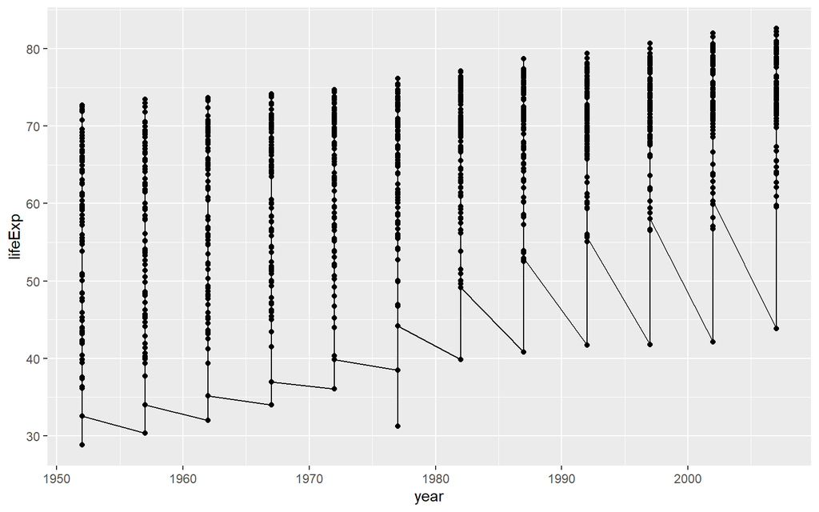

```r
gm %>%
  ggplot(aes(year, lifeExp)) +
  geom_point() +
  geom_line()
```

The `geom_line` function works best with summarized/grouped data.

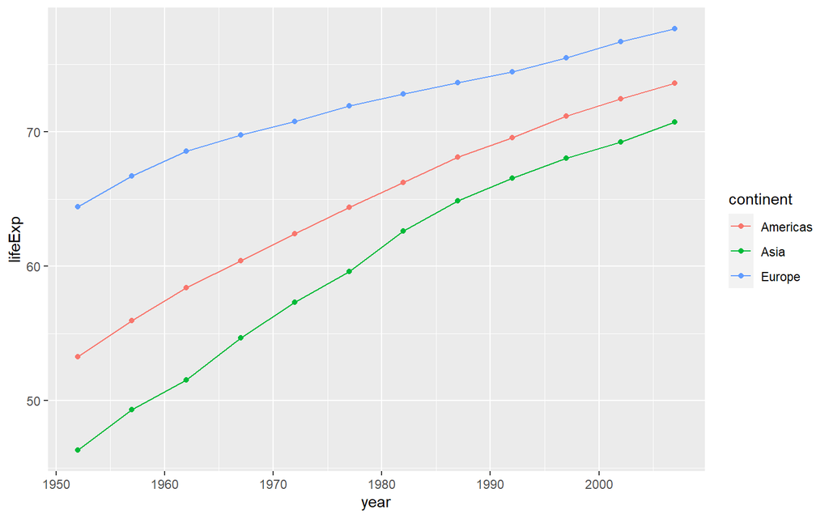

```r
gm %>%
  group_by(continent, year) %>%
  summarize(lifeExp = mean(lifeExp, na.rm = TRUE)) %>%
  ggplot(aes(year, lifeExp, color = continent)) +
  geom_point() +
  geom_line()
```

Below, I have customized a connected line chart using the `ggrepel` package. This package contains the `geom_text_repel` function that allows you to add text to your plots in an efficient manner. To ensure that the label does not show up at every point in the graph, I created a label variable that will only be created for the year 2007.

```r
install.packages("ggrepel")
```

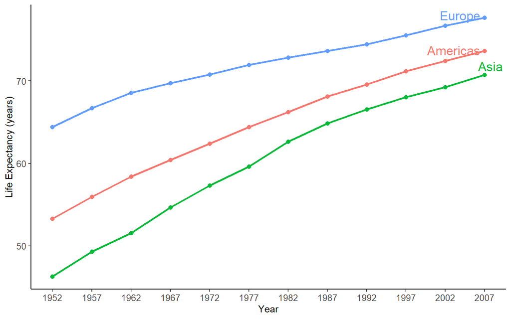

```r
library(ggrepel)
gm %>%
  group_by(continent, year) %>%
  summarize(lifeExp = mean(lifeExp, na.rm = TRUE)) %>%
  mutate(label = if_else(year == 2007, paste0(continent), "")) %>%
  ggplot(aes(year, lifeExp, color = continent)) +
  geom_point(size = 2) +
  geom_line(size = 1) +
  geom_text_repel(aes(label = label),
                  size = 5) +
  theme_classic() +
  theme(legend.position = "none",
        axis.text = element_text(size = 10)) +
  scale_x_continuous(breaks=seq(min(gm$year),
                                max(gm$year),
                                5)) +
  labs(x = "Year", y = "Life Expectancy (years)")
```

Finally, notice the `scale_x_continuous` function. Using the `seq` function I was able to create axis ticks that match up directly with the min/max and intervals that are in the dataset. The `scale` family of functions are very helpful for changing the way the axes are laid out.

## `tidyr`

The `tidyr` package provides tools to manipulate and organize data in a quick and efficient manner. The goal of the package is to create tidy data, where the data can be easily read, analyzed and visualized and is free from errors. This includes removing multiple pieces of data encoded in a single column, reshaping datasets, and adding datasets together

We are going to use a smaller version of our `nh` dataset to illustrate some of the functions from the `tidyr` package.

```r
nh_smaller <- nh %>%
  mutate(BP = paste0(BPSysAve, "/", BPDiaAve)) %>%
  select(1:8, BP) %>%
  head(100) %>%
  group_by(ID) %>%
  mutate(visit = row_number())
```

### Separate & Unite

In looking at the output of the `nh_smaller` dataset, we have some work to do to tidy the data for analysis.

```r
nh_smaller
```

```
## # A tibble: 100 × 10
## # Groups:   ID [69]
##       ID SurveyYr Gender   Age AgeDecade AgeMonths Race1 Race3 BP     visit
##    <dbl> <chr>    <chr>  <dbl> <chr>         <dbl> <chr> <chr> <chr>  <int>
##  1 51624 2009_10  male      34 30-39           409 White <NA>  113/85     1
##  2 51624 2009_10  male      34 30-39           409 White <NA>  113/85     2
##  3 51624 2009_10  male      34 30-39           409 White <NA>  113/85     3
##  4 51625 2009_10  male       4 0-9              49 Other <NA>  NA/NA      1
##  5 51630 2009_10  female    49 40-49           596 White <NA>  112/75     1
##  6 51638 2009_10  male       9 0-9             115 White <NA>  86/47      1
##  7 51646 2009_10  male       8 0-9             101 White <NA>  107/37     1
##  8 51647 2009_10  female    45 40-49           541 White <NA>  118/64     1
##  9 51647 2009_10  female    45 40-49           541 White <NA>  118/64     2
## 10 51647 2009_10  female    45 40-49           541 White <NA>  118/64     3
## # … with 90 more rows
```

One of the first problems I see is that there are multiple pieces of data encoded into the column called `BP`. Luckily, the data are separated neatly by `/`. Let’s use the separate function from the tidyr package to create new columns from the original `/` column.

#### Separate

The `separate` function is used to create multiple columns from a single column. For the `separate` function you simply need the dataset, the column you want to separate into multiple columns, the name of the new columns, and the means by which the column is separated.

```r
nh_bp <- nh_smaller %>%
  separate(col = BP, into = c("BPSYS", "BPDIA"), sep = "/")
nh_bp
```

Make sure to look at the variable types after a `separate`, they can often show everything as character/string/factor, when you would expect it to be numeric

```r
nh_bp <- nh_bp %>%
  mutate(BPSYS = as.numeric(BPSYS),
         BPDIA = as.numeric(BPDIA))
```

If the separator was not as neat as this, you can input any [regular expression](https://en.wikipedia.org/wiki/Regular_expression) into the separator argument.

#### Resources for Regular Expressions

For a nice cheatsheet for writing regular expressions in R, see a [Regex cheatsheet](http://www.cbs.dtu.dk/courses/27610/regular-expressions-cheat-sheet-v2.pdf). Jenny Bryan has created a nice website tutorial for learning to use [Regular Expressions in R](http://stat545.com/block022_regular-expression.html).

#### Unite

`unite` is essentially the opposite of `separate`. It acts much like paste would work, where it combines two (or more) separate columns into one while separating with a specific value

```r
# Let's pretend we want to unite the two Blood Pressure
# Readings together from nh_bp
nh_bp %>%
  unite(col = BP, c("BPSYS", "BPDIA"), sep = "/") %>%
  select(BP)
```

```
## # A tibble: 100 × 2
## # Groups:   ID [69]
##       ID BP
##    <dbl> <chr>
##  1 51624 113/85
##  2 51624 113/85
##  3 51624 113/85
##  4 51625 NA/NA
##  5 51630 112/75
##  6 51638 86/47
##  7 51646 107/37
##  8 51647 118/64
##  9 51647 118/64
## 10 51647 118/64
## # … with 90 more rows
```

### Reshaping - pivot_wider & pivot_longer

The next problem with data wrangling is reshaping the dataframe. Notice that we have several rows that seem to be encoding health information for duplicate patients when we look at the `nh_bp` dataset. At times, we want the dataset to be set up like this, in a longitudinal manner. But, sometimes you want all of the information for a given patient in one single row.

```r
nh_bp %>%
  arrange(ID, visit)
```

The `ID` column is repeated across the patients for each visit This longitudinal/panel style of dataset is considered a `long` dataset, where you have many observations and few columns/variables. This set up is nice for looking at time series or repeated measures. However, we want to turn it into a `wide` dataset, where there are more variables and fewer observations.

We will use the `pivot_wider` function to change our dataset from `long` to `wide`. Conversely the `pivot_longer` function changes a dataset from `wide` to `long`.

After the dataframe, `pivot_wider()` needs 2 other arguments. The first one is where you are getting your new variable names from. Since you will be creating several variables, R needs a way to tell how to name them. The second argument, below tells us where to get the values for the new variables.

```r
names(nh_bp)
nh_bp  %>%
  pivot_wider(names_from = visit, values_from = c("BPSYS", "BPDIA"))

nh_bp_wide <- nh_bp  %>%
  pivot_wider(names_from = visit, values_from = c("BPSYS", "BPDIA"))
```

Using `names_prefix` is helpful when dealing with troublesome/unhelpful names

```r
nh_bp %>%
  pivot_wider(names_from = visit, values_from = c("BPSYS", "BPDIA"), names_prefix = "Visit_")
```

```
## # A tibble: 69 × 16
## # Groups:   ID [69]
##       ID SurveyYr Gender   Age AgeDecade AgeMonths Race1 Race3 BPSYS_V…¹ BPSYS…²
##    <dbl> <chr>    <chr>  <dbl> <chr>         <dbl> <chr> <chr>     <dbl>   <dbl>
##  1 51624 2009_10  male      34 30-39           409 White <NA>        113     113
##  2 51625 2009_10  male       4 0-9              49 Other <NA>         NA      NA
##  3 51630 2009_10  female    49 40-49           596 White <NA>        112      NA
##  4 51638 2009_10  male       9 0-9             115 White <NA>         86      NA
##  5 51646 2009_10  male       8 0-9             101 White <NA>        107      NA
##  6 51647 2009_10  female    45 40-49           541 White <NA>        118     118
##  7 51654 2009_10  male      66 60-69           795 White <NA>        111      NA
##  8 51656 2009_10  male      58 50-59           707 White <NA>        104      NA
##  9 51657 2009_10  male      54 50-59           654 White <NA>        134      NA
## 10 51659 2009_10  female    10 10-19           123 White <NA>        104      NA
## # … with 59 more rows, 6 more variables: BPSYS_Visit_3 <dbl>,
## #   BPSYS_Visit_4 <dbl>, BPDIA_Visit_1 <dbl>, BPDIA_Visit_2 <dbl>,
## #   BPDIA_Visit_3 <dbl>, BPDIA_Visit_4 <dbl>, and abbreviated variable names
## #   ¹BPSYS_Visit_1, ²BPSYS_Visit_2
```

As mentioned earlier, `pivot_longer()` is the inverse of `pivot_wider`. With `pivot_longer()` you tell R the columns that you want to gather and then the name for the new column you are creating. Notice here the `:` operator which basically means “through”. The `nh_bp_wide` dataset is an example of a wide dataset. So here we are grabbing all variables from `BPSYS_1` through `BPDIA_4`.

```r
nh_bp_wide
```

```
## # A tibble: 69 × 16
## # Groups:   ID [69]
##       ID SurveyYr Gender   Age AgeDecade AgeMonths Race1 Race3 BPSYS_1 BPSYS_2
##    <dbl> <chr>    <chr>  <dbl> <chr>         <dbl> <chr> <chr>   <dbl>   <dbl>
##  1 51624 2009_10  male      34 30-39           409 White <NA>      113     113
##  2 51625 2009_10  male       4 0-9              49 Other <NA>       NA      NA
##  3 51630 2009_10  female    49 40-49           596 White <NA>      112      NA
##  4 51638 2009_10  male       9 0-9             115 White <NA>       86      NA
##  5 51646 2009_10  male       8 0-9             101 White <NA>      107      NA
##  6 51647 2009_10  female    45 40-49           541 White <NA>      118     118
##  7 51654 2009_10  male      66 60-69           795 White <NA>      111      NA
##  8 51656 2009_10  male      58 50-59           707 White <NA>      104      NA
##  9 51657 2009_10  male      54 50-59           654 White <NA>      134      NA
## 10 51659 2009_10  female    10 10-19           123 White <NA>      104      NA
## # … with 59 more rows, and 6 more variables: BPSYS_3 <dbl>, BPSYS_4 <dbl>,
## #   BPDIA_1 <dbl>, BPDIA_2 <dbl>, BPDIA_3 <dbl>, BPDIA_4 <dbl>
```

```r
nh_bp_long <- nh_bp_wide %>%
  pivot_longer(cols = BPSYS_1:BPDIA_4)
```

The `rename` function from `dplyr` allows you to `rename` variables quickly and easily by putting in the new variable name and then the old variable name.

```r
nh_bp_long
```

```
## # A tibble: 552 × 10
## # Groups:   ID [69]
##       ID SurveyYr Gender   Age AgeDecade AgeMonths Race1 Race3 name    value
##    <dbl> <chr>    <chr>  <dbl> <chr>         <dbl> <chr> <chr> <chr>   <dbl>
##  1 51624 2009_10  male      34 30-39           409 White <NA>  BPSYS_1   113
##  2 51624 2009_10  male      34 30-39           409 White <NA>  BPSYS_2   113
##  3 51624 2009_10  male      34 30-39           409 White <NA>  BPSYS_3   113
##  4 51624 2009_10  male      34 30-39           409 White <NA>  BPSYS_4    NA
##  5 51624 2009_10  male      34 30-39           409 White <NA>  BPDIA_1    85
##  6 51624 2009_10  male      34 30-39           409 White <NA>  BPDIA_2    85
##  7 51624 2009_10  male      34 30-39           409 White <NA>  BPDIA_3    85
##  8 51624 2009_10  male      34 30-39           409 White <NA>  BPDIA_4    NA
##  9 51625 2009_10  male       4 0-9              49 Other <NA>  BPSYS_1    NA
## 10 51625 2009_10  male       4 0-9              49 Other <NA>  BPSYS_2    NA
## # … with 542 more rows
```

```r
nh_bp_long <- nh_bp_long %>%
  rename(BP_Type = name, BP_Reading = value)
```

### Merging Datasets Together with `_join`

Oftentimes you want to add more information/observations to a dataset that you already have. To do this, you need to merge datasets together using the `_join` family of functions. To successfully merge an observation from one dataset to another you have to have a common variable or common variables across the datasets that will match.

I am going to create a couple of smaller dataframes out of the gapminder dataset in order to illustrate the different types of joins.

```r
x <- gm %>%
  filter(year == 2007) %>%
  select(country, continent, year, lifeExp) %>%
  arrange(country) %>%
  head(10) %>%
  mutate(dataset = "x")

y <- gm %>%
  filter(year >= 2000) %>%
  select(country, continent, year, pop, gdpPercap) %>%
  arrange(country) %>%
  head(10) %>%
  mutate(dataset = "y")

x
```

```
## # A tibble: 10 × 5
##    country                continent  year lifeExp dataset
##    <fct>                  <fct>     <int>   <dbl> <chr>
##  1 Afghanistan            Asia       2007    43.8 x
##  2 Albania                Europe     2007    76.4 x
##  3 Argentina              Americas   2007    75.3 x
##  4 Austria                Europe     2007    79.8 x
##  5 Bahrain                Asia       2007    75.6 x
##  6 Bangladesh             Asia       2007    64.1 x
##  7 Belgium                Europe     2007    79.4 x
##  8 Bolivia                Americas   2007    65.6 x
##  9 Bosnia and Herzegovina Europe     2007    74.9 x
## 10 Brazil                 Americas   2007    72.4 x
```

```r
y
```

```
## # A tibble: 10 × 6
##    country     continent  year      pop gdpPercap dataset
##    <fct>       <fct>     <int>    <int>     <dbl> <chr>
##  1 Afghanistan Asia       2002 25268405      727. y
##  2 Afghanistan Asia       2007 31889923      975. y
##  3 Albania     Europe     2002  3508512     4604. y
##  4 Albania     Europe     2007  3600523     5937. y
##  5 Argentina   Americas   2002 38331121     8798. y
##  6 Argentina   Americas   2007 40301927    12779. y
##  7 Austria     Europe     2002  8148312    32418. y
##  8 Austria     Europe     2007  8199783    36126. y
##  9 Bahrain     Asia       2002   656397    23404. y
## 10 Bahrain     Asia       2007   708573    29796. y
```

There are several types of joins (merges) that we can use. The one you use depends upon your specific needs.

`inner_join()`: return all rows from x where there are matching values in y, and all columns from x and y. If there are multiple matches between x and y, all combination of the matches are returned.

The key argument here is the `by` argument that illustrates how you want to match your datasets. This is equivalent to the idea of a primary/foreign key in database terms.

```r
inner_join(x, y, by = c("country", "continent", "year"))
```

```
## # A tibble: 5 × 8
##   country     continent  year lifeExp dataset.x      pop gdpPercap dataset.y
##   <fct>       <fct>     <int>   <dbl> <chr>        <int>     <dbl> <chr>
## 1 Afghanistan Asia       2007    43.8 x         31889923      975. y
## 2 Albania     Europe     2007    76.4 x          3600523     5937. y
## 3 Argentina   Americas   2007    75.3 x         40301927    12779. y
## 4 Austria     Europe     2007    79.8 x          8199783    36126. y
## 5 Bahrain     Asia       2007    75.6 x           708573    29796. y
```

As you can see, we only have 5 perfect matches on country, continent, and year. Also notice when merging datasets, any columns that are not included in the `by` argument and have the same name as a column in the other dataset will have a suffix appended with `.x` or `.y` depending on whether they come from the left (x) or right (y) dataset.

`left_join()`: return all rows from x, and all columns from x and y. Rows in x with no match in y will have NA values in the new columns. If there are multiple matches between x and y, all combinations of the matches are returned.

```r
left_join(x, y, by = c("country", "continent", "year"))
```

```
## # A tibble: 10 × 8
##    country                contin…¹  year lifeExp datas…²     pop gdpPe…³ datas…⁴
##    <fct>                  <fct>    <int>   <dbl> <chr>     <int>   <dbl> <chr>
##  1 Afghanistan            Asia      2007    43.8 x        3.19e7    975. y
##  2 Albania                Europe    2007    76.4 x        3.60e6   5937. y
##  3 Argentina              Americas  2007    75.3 x        4.03e7  12779. y
##  4 Austria                Europe    2007    79.8 x        8.20e6  36126. y
##  5 Bahrain                Asia      2007    75.6 x        7.09e5  29796. y
##  6 Bangladesh             Asia      2007    64.1 x       NA          NA  <NA>
##  7 Belgium                Europe    2007    79.4 x       NA          NA  <NA>
##  8 Bolivia                Americas  2007    65.6 x       NA          NA  <NA>
##  9 Bosnia and Herzegovina Europe    2007    74.9 x       NA          NA  <NA>
## 10 Brazil                 Americas  2007    72.4 x       NA          NA  <NA>
## # … with abbreviated variable names ¹continent, ²dataset.x, ³gdpPercap,
## #   ⁴dataset.y
```

Here we are returned all 10 observations from the left (x) dataset, however, only 5 observations from the right (y) dataset are matched.

`right_join()`: return all rows from y, and all columns from x and y. Rows in y with no match in x will have NA values in the new columns. If there are multiple matches between x and y, all combinations of the matches are returned.

```r
right_join(x, y, by = c("country", "continent", "year"))
```

```
## # A tibble: 10 × 8
##    country     continent  year lifeExp dataset.x      pop gdpPercap dataset.y
##    <fct>       <fct>     <int>   <dbl> <chr>        <int>     <dbl> <chr>
##  1 Afghanistan Asia       2007    43.8 x         31889923      975. y
##  2 Albania     Europe     2007    76.4 x          3600523     5937. y
##  3 Argentina   Americas   2007    75.3 x         40301927    12779. y
##  4 Austria     Europe     2007    79.8 x          8199783    36126. y
##  5 Bahrain     Asia       2007    75.6 x           708573    29796. y
##  6 Afghanistan Asia       2002    NA   <NA>      25268405      727. y
##  7 Albania     Europe     2002    NA   <NA>       3508512     4604. y
##  8 Argentina   Americas   2002    NA   <NA>      38331121     8798. y
##  9 Austria     Europe     2002    NA   <NA>       8148312    32418. y
## 10 Bahrain     Asia       2002    NA   <NA>        656397    23404. y
```

Again, here we match on only 5 observation but we keep all of the observation from our right (y) dataset.

`full_join()`: return all rows and all columns from both x and y. Where there are not matching values, returns NA for the one missing.

```r
full_join(x, y, by = c("country", "continent", "year"))
```

```
## # A tibble: 15 × 8
##    country                contin…¹  year lifeExp datas…²     pop gdpPe…³ datas…⁴
##    <fct>                  <fct>    <int>   <dbl> <chr>     <int>   <dbl> <chr>
##  1 Afghanistan            Asia      2007    43.8 x        3.19e7    975. y
##  2 Albania                Europe    2007    76.4 x        3.60e6   5937. y
##  3 Argentina              Americas  2007    75.3 x        4.03e7  12779. y
##  4 Austria                Europe    2007    79.8 x        8.20e6  36126. y
##  5 Bahrain                Asia      2007    75.6 x        7.09e5  29796. y
##  6 Bangladesh             Asia      2007    64.1 x       NA          NA  <NA>
##  7 Belgium                Europe    2007    79.4 x       NA          NA  <NA>
##  8 Bolivia                Americas  2007    65.6 x       NA          NA  <NA>
##  9 Bosnia and Herzegovina Europe    2007    74.9 x       NA          NA  <NA>
## 10 Brazil                 Americas  2007    72.4 x       NA          NA  <NA>
## 11 Afghanistan            Asia      2002    NA   <NA>     2.53e7    727. y
## 12 Albania                Europe    2002    NA   <NA>     3.51e6   4604. y
## 13 Argentina              Americas  2002    NA   <NA>     3.83e7   8798. y
## 14 Austria                Europe    2002    NA   <NA>     8.15e6  32418. y
## 15 Bahrain                Asia      2002    NA   <NA>     6.56e5  23404. y
## # … with abbreviated variable names ¹continent, ²dataset.x, ³gdpPercap,
## #   ⁴dataset.y
```

Finally, this keeps all observations whether there was a match or not.

### Other ways to combine variables and cases

The `join` functions have some intelligence to their actions. However, you can use a couple of `bind` functions to simply add variables or cases to existing datasets.

Use `bind_cols()` to paste tables beside each other as they are. Use `bind_rows()` to paste tables below each other as they are.

```r
a <- nh_bp_wide[1:3,]
b <- nh_bp_wide[6:8,]
a
```

```
## # A tibble: 3 × 16
## # Groups:   ID [3]
##      ID Surve…¹ Gender   Age AgeDe…² AgeMo…³ Race1 Race3 BPSYS_1 BPSYS_2 BPSYS_3
##   <dbl> <chr>   <chr>  <dbl> <chr>     <dbl> <chr> <chr>   <dbl>   <dbl>   <dbl>
## 1 51624 2009_10 male      34 30-39       409 White <NA>      113     113     113
## 2 51625 2009_10 male       4 0-9          49 Other <NA>       NA      NA      NA
## 3 51630 2009_10 female    49 40-49       596 White <NA>      112      NA      NA
## # … with 5 more variables: BPSYS_4 <dbl>, BPDIA_1 <dbl>, BPDIA_2 <dbl>,
## #   BPDIA_3 <dbl>, BPDIA_4 <dbl>, and abbreviated variable names ¹SurveyYr,
## #   ²AgeDecade, ³AgeMonths
```

```r
b
```

```
## # A tibble: 3 × 16
## # Groups:   ID [3]
##      ID Surve…¹ Gender   Age AgeDe…² AgeMo…³ Race1 Race3 BPSYS_1 BPSYS_2 BPSYS_3
##   <dbl> <chr>   <chr>  <dbl> <chr>     <dbl> <chr> <chr>   <dbl>   <dbl>   <dbl>
## 1 51647 2009_10 female    45 40-49       541 White <NA>      118     118     118
## 2 51654 2009_10 male      66 60-69       795 White <NA>      111      NA      NA
## 3 51656 2009_10 male      58 50-59       707 White <NA>      104      NA      NA
## # … with 5 more variables: BPSYS_4 <dbl>, BPDIA_1 <dbl>, BPDIA_2 <dbl>,
## #   BPDIA_3 <dbl>, BPDIA_4 <dbl>, and abbreviated variable names ¹SurveyYr,
## #   ²AgeDecade, ³AgeMonths
```

```r
bind_rows(a, b)
```

```
## # A tibble: 6 × 16
## # Groups:   ID [6]
##      ID Surve…¹ Gender   Age AgeDe…² AgeMo…³ Race1 Race3 BPSYS_1 BPSYS_2 BPSYS_3
##   <dbl> <chr>   <chr>  <dbl> <chr>     <dbl> <chr> <chr>   <dbl>   <dbl>   <dbl>
## 1 51624 2009_10 male      34 30-39       409 White <NA>      113     113     113
## 2 51625 2009_10 male       4 0-9          49 Other <NA>       NA      NA      NA
## 3 51630 2009_10 female    49 40-49       596 White <NA>      112      NA      NA
## 4 51647 2009_10 female    45 40-49       541 White <NA>      118     118     118
## 5 51654 2009_10 male      66 60-69       795 White <NA>      111      NA      NA
## 6 51656 2009_10 male      58 50-59       707 White <NA>      104      NA      NA
## # … with 5 more variables: BPSYS_4 <dbl>, BPDIA_1 <dbl>, BPDIA_2 <dbl>,
## #   BPDIA_3 <dbl>, BPDIA_4 <dbl>, and abbreviated variable names ¹SurveyYr,
## #   ²AgeDecade, ³AgeMonths
```

```r
c <- nh_bp_wide[, 1]
d <- nh_bp_wide[, 3]
c
```

```
## # A tibble: 69 × 1
## # Groups:   ID [69]
##       ID
##    <dbl>
##  1 51624
##  2 51625
##  3 51630
##  4 51638
##  5 51646
##  6 51647
##  7 51654
##  8 51656
##  9 51657
## 10 51659
## # … with 59 more rows
```

```r
d
```

```
## # A tibble: 69 × 1
##    Gender
##    <chr>
##  1 male
##  2 male
##  3 female
##  4 male
##  5 male
##  6 female
##  7 male
##  8 male
##  9 male
## 10 female
## # … with 59 more rows
```

```r
bind_cols(c, d)
```

```
## # A tibble: 69 × 2
## # Groups:   ID [69]
##       ID Gender
##    <dbl> <chr>
##  1 51624 male
##  2 51625 male
##  3 51630 female
##  4 51638 male
##  5 51646 male
##  6 51647 female
##  7 51654 male
##  8 51656 male
##  9 51657 male
## 10 51659 female
## # … with 59 more rows
```

## `purrr`

The `purrr` package allows you to programmatically work within the tidyverse. The package provides a consistent way to interact with functions, either built-in functions or user built functions. Utilizing functions and the `purrr` package allows for efficient code that is easier to troubleshoot and debug.

The most basic function within the purrr package is the `map()` function. The `map` function takes a piece of input (vector, list, dataframe) and applies a function to that input. `purrr` will return the output in whatever format is the default for the function. The map function returns a list. However, you have plenty of options when it comes to the type of output that you want to use. For instance, by changing map to `map_dbl`, you can return a double vector. There are other options for this as well, such as `map_int`, `map_lgl`, and `map_chr` that return integers, logical, and character vectors respectively.

```r
mtcars
```

```
##                      mpg cyl  disp  hp drat    wt  qsec vs am gear carb
## Mazda RX4           21.0   6 160.0 110 3.90 2.620 16.46  0  1    4    4
## Mazda RX4 Wag       21.0   6 160.0 110 3.90 2.875 17.02  0  1    4    4
## Datsun 710          22.8   4 108.0  93 3.85 2.320 18.61  1  1    4    1
## Hornet 4 Drive      21.4   6 258.0 110 3.08 3.215 19.44  1  0    3    1
## Hornet Sportabout   18.7   8 360.0 175 3.15 3.440 17.02  0  0    3    2
## Valiant             18.1   6 225.0 105 2.76 3.460 20.22  1  0    3    1
## Duster 360          14.3   8 360.0 245 3.21 3.570 15.84  0  0    3    4
## Merc 240D           24.4   4 146.7  62 3.69 3.190 20.00  1  0    4    2
## Merc 230            22.8   4 140.8  95 3.92 3.150 22.90  1  0    4    2
## Merc 280            19.2   6 167.6 123 3.92 3.440 18.30  1  0    4    4
## Merc 280C           17.8   6 167.6 123 3.92 3.440 18.90  1  0    4    4
## Merc 450SE          16.4   8 275.8 180 3.07 4.070 17.40  0  0    3    3
## Merc 450SL          17.3   8 275.8 180 3.07 3.730 17.60  0  0    3    3
## Merc 450SLC         15.2   8 275.8 180 3.07 3.780 18.00  0  0    3    3
## Cadillac Fleetwood  10.4   8 472.0 205 2.93 5.250 17.98  0  0    3    4
## Lincoln Continental 10.4   8 460.0 215 3.00 5.424 17.82  0  0    3    4
## Chrysler Imperial   14.7   8 440.0 230 3.23 5.345 17.42  0  0    3    4
## Fiat 128            32.4   4  78.7  66 4.08 2.200 19.47  1  1    4    1
## Honda Civic         30.4   4  75.7  52 4.93 1.615 18.52  1  1    4    2
## Toyota Corolla      33.9   4  71.1  65 4.22 1.835 19.90  1  1    4    1
## Toyota Corona       21.5   4 120.1  97 3.70 2.465 20.01  1  0    3    1
## Dodge Challenger    15.5   8 318.0 150 2.76 3.520 16.87  0  0    3    2
## AMC Javelin         15.2   8 304.0 150 3.15 3.435 17.30  0  0    3    2
## Camaro Z28          13.3   8 350.0 245 3.73 3.840 15.41  0  0    3    4
## Pontiac Firebird    19.2   8 400.0 175 3.08 3.845 17.05  0  0    3    2
## Fiat X1-9           27.3   4  79.0  66 4.08 1.935 18.90  1  1    4    1
## Porsche 914-2       26.0   4 120.3  91 4.43 2.140 16.70  0  1    5    2
## Lotus Europa        30.4   4  95.1 113 3.77 1.513 16.90  1  1    5    2
## Ford Pantera L      15.8   8 351.0 264 4.22 3.170 14.50  0  1    5    4
## Ferrari Dino        19.7   6 145.0 175 3.62 2.770 15.50  0  1    5    6
## Maserati Bora       15.0   8 301.0 335 3.54 3.570 14.60  0  1    5    8
## Volvo 142E          21.4   4 121.0 109 4.11 2.780 18.60  1  1    4    2
```

```r
# map returns a list
mtcars %>%
map(mean)
```

```
## $mpg
## [1] 20.09062
##
## $cyl
## [1] 6.1875
##
## $disp
## [1] 230.7219
##
## $hp
## [1] 146.6875
##
## $drat
## [1] 3.596563
##
## $wt
## [1] 3.21725
##
## $qsec
## [1] 17.84875
##
## $vs
## [1] 0.4375
##
## $am
## [1] 0.40625
##
## $gear
## [1] 3.6875
##
## $carb
## [1] 2.8125
```

`map_dbl` returns a double vector

```r
mtcars %>%
  map_dbl(mean)
```

```
##        mpg        cyl       disp         hp       drat         wt       qsec
##  20.090625   6.187500 230.721875 146.687500   3.596563   3.217250  17.848750
##         vs         am       gear       carb
##   0.437500   0.406250   3.687500   2.812500
```

`map_lgl` returns a logical vector (T/F)

```r
mtcars %>%
  map_lgl(is.character)
```

```
##   mpg   cyl  disp    hp  drat    wt  qsec    vs    am  gear  carb
## FALSE FALSE FALSE FALSE FALSE FALSE FALSE FALSE FALSE FALSE FALSE
```

```r
mtcars %>%
  map_lgl(is.numeric)
```

```
##  mpg  cyl disp   hp drat   wt qsec   vs   am gear carb
## TRUE TRUE TRUE TRUE TRUE TRUE TRUE TRUE TRUE TRUE TRUE
```

### Using Your Own Functions

In the first chunk of code we used built-in functions. However, real power comes when you start to write and utilize your own functions.

The function below takes in input (x) and will find the number of unique values within that input. The input could simply be a vector of values all the way to a multidimensional list.

```r
n_unique <- function(x) length(unique(x))

# map_int
mtcars %>%
  map_int(n_unique)
```

```
##  mpg  cyl disp   hp drat   wt qsec   vs   am gear carb
##   25    3   27   22   22   29   30    2    2    3    6
```

The following function, `replace_As`, will replace all “A”s that are upper or lower case with the word “replaced.” The `select_if` function below comes from the `dplyr` package and will select only those variables that are a factor.

```r
gm <- gapminder::gapminder
gm
```

```
## # A tibble: 1,704 × 6
##    country     continent  year lifeExp      pop gdpPercap
##    <fct>       <fct>     <int>   <dbl>    <int>     <dbl>
##  1 Afghanistan Asia       1952    28.8  8425333      779.
##  2 Afghanistan Asia       1957    30.3  9240934      821.
##  3 Afghanistan Asia       1962    32.0 10267083      853.
##  4 Afghanistan Asia       1967    34.0 11537966      836.
##  5 Afghanistan Asia       1972    36.1 13079460      740.
##  6 Afghanistan Asia       1977    38.4 14880372      786.
##  7 Afghanistan Asia       1982    39.9 12881816      978.
##  8 Afghanistan Asia       1987    40.8 13867957      852.
##  9 Afghanistan Asia       1992    41.7 16317921      649.
## 10 Afghanistan Asia       1997    41.8 22227415      635.
## # … with 1,694 more rows
```

```r
replace_As <- function(x) str_replace_all(x, "A|a", "replaced")

gm %>%
  select_if(is.factor) %>%
  sample_n(50) %>%
  map(replace_As)
```

```
## $country
##  [1] "Chile"
##  [2] "Threplacedilreplacednd"
##  [3] "Chile"
##  [4] "Hondurreplaceds"
##  [5] "Benin"
##  [6] "Guinereplaced"
##  [7] "replacedustrreplacedlireplaced"
##  [8] "Hondurreplaceds"
##  [9] "Bolivireplaced"
## [10] "Bosnireplaced replacednd Herzegovinreplaced"
## [11] "Eritrereplaced"
## [12] "replacedlgerireplaced"
## [13] "Bulgreplacedrireplaced"
## [14] "South replacedfricreplaced"
```

[output cut: 55 more lines]

The `modify_if` function will do something similar and will only use the `replace_As` function on a factor variable.

```r
gm %>%
  sample_n(50) %>%
  modify_if(is.factor, replace_As)
```

```
## # A tibble: 50 × 6
##    country                                  conti…¹  year lifeExp    pop gdpPe…²
##    <chr>                                    <chr>   <int>   <dbl>  <int>   <dbl>
##  1 Sweden                                   Europe   1952    71.9 7.12e6   8528.
##  2 Peru                                     replac…  1992    66.5 2.24e7   4446.
##  3 West Breplacednk replacednd Greplacedzr… replac…  1952    43.2 1.03e6   1516.
##  4 Myreplacednmreplacedr                    replac…  1992    59.3 4.05e7    347
##  5 Dominicreplacedn Republic                replac…  1977    61.8 5.30e6   2682.
##  6 Senegreplacedl                           replac…  2007    63.1 1.23e7   1712.
##  7 Hreplacediti                             replac…  1972    48.0 4.70e6   1654.
##  8 Creplacedmeroon                          replac…  1967    44.8 6.34e6   1508.
##  9 Liberireplaced                           replac…  1997    42.2 2.20e6    609.
## 10 Portugreplacedl                          Europe   1972    69.3 8.97e6   9022.
## # … with 40 more rows, and abbreviated variable names ¹continent, ²gdpPercap
```

The next option I want to show is the use of `purrr` to be able to read and write many files.

```r
# Split by variable
sp_gm <- split(gm, gm$year)

# Save Function
saver <- function(x) readr::write_csv(sp_gm[[x]], file = paste0("Data/gm_", x, ".csv", sep = ""))

map(names(sp_gm), saver)
```

To read the data back in you can use the `list.files` function that allows you to provide a pattern that you want to match. This pattern uses regular expressions that allow for complicated file names. Below, the pattern essentially says that the file name should start with gm_ and end with csv. (Example: gm2007.csv)

```r
list_of_files <- list.files(path = "Data/",
                            recursive = TRUE,
                            pattern = "^[gm_].*[csv]$",
                            full.names = TRUE)
```

```r
gm_new <- list_of_files %>%
  purrr::set_names(nm = (basename(.) %>%  tools::file_path_sans_ext())) %>%
  purrr::map_df(read_csv)

gm_new
```

```
## # A tibble: 0 × 0
```

Below is a more advanced example of how you can use a function from `purrr` called the `walk` function. Below, we are creating a function that creates a graph and allows you to iterate over a series of variables instead of having to graph each column one by one. It also saves the graphs as you move on.

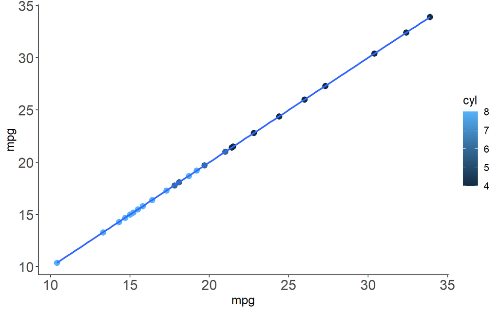

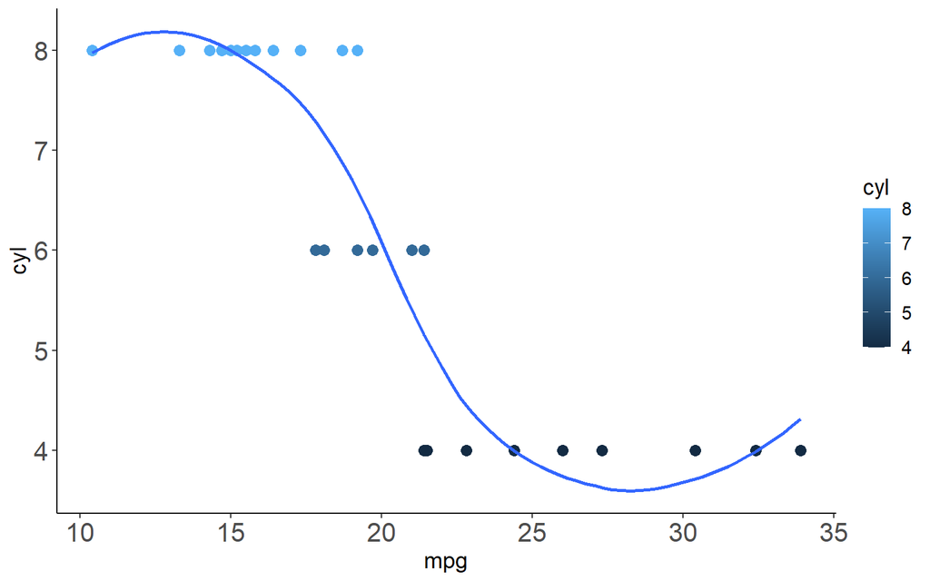

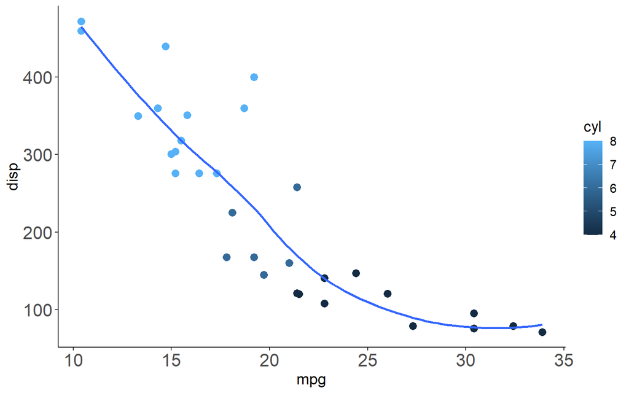

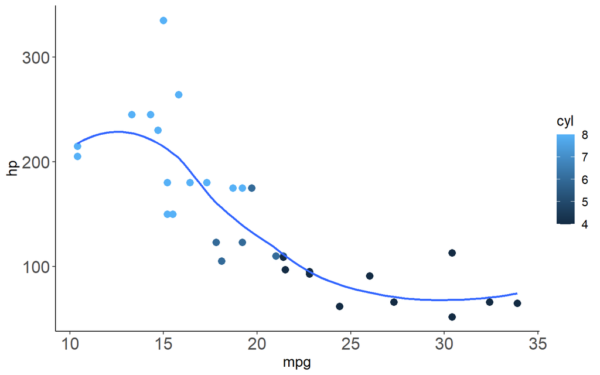

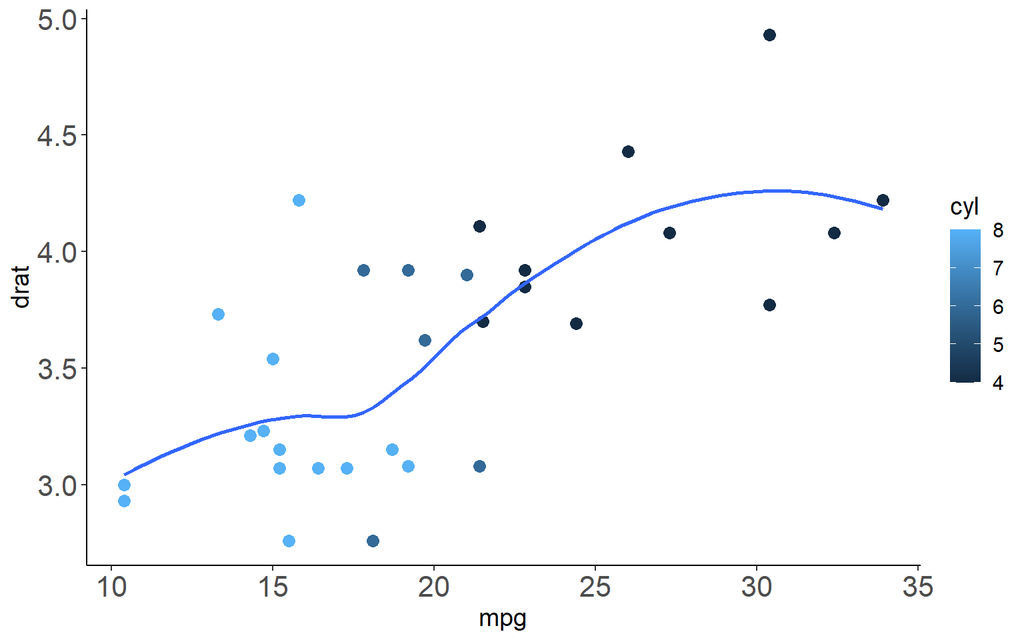

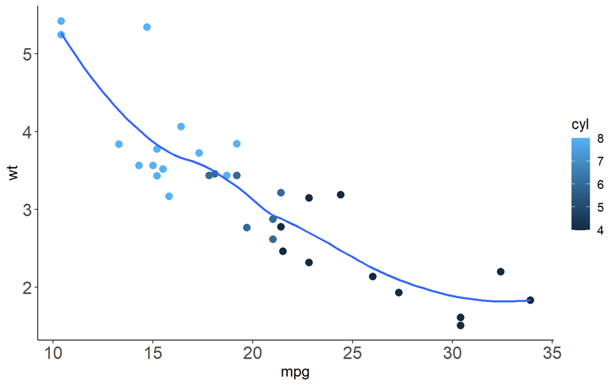

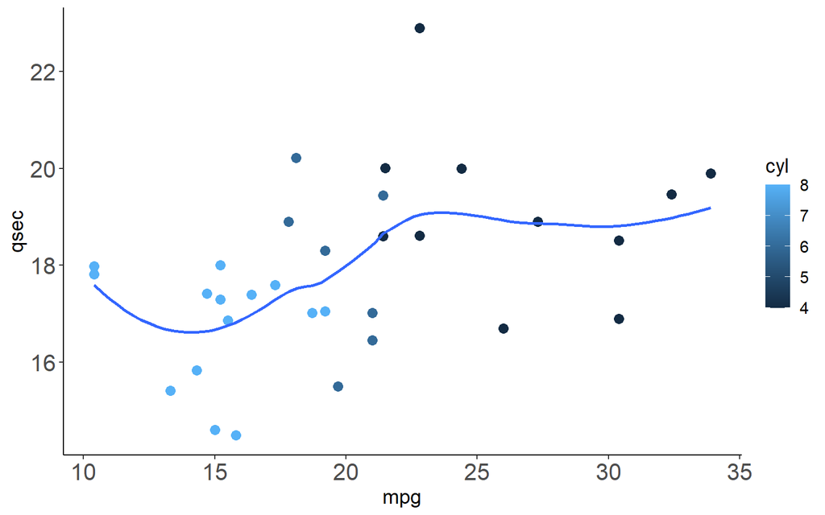

```r
mtcars_small <- mtcars %>%
  select(mpg:qsec)

cars_plot <- function(dataset = mtcars_small, xvar = "mpg", yvar) {
  p <- ggplot(dataset, aes_string(x = xvar, y = yvar)) +
    geom_point(aes(color = cyl), size = 3) +
    geom_smooth(aes(color = cyl), se = FALSE) +
    theme_classic() +
    theme(text=element_text(family = "Times", size=14),
          axis.text.x = element_text(size=16),
          axis.text.y = element_text(size=16))
    print(p)
  ggsave(p, filename = paste0("Graphs/", yvar, "_plot.png"), width = 4, height = 4, device = "png")
  }
car_names <- mtcars_small %>%
  t() %>%
  rownames()

car_names %>% walk(~cars_plot(yvar = .x))
```

## Expanding on dplyr

The final piece I want to look at are similar to `purrr` functions and they allow you to make changes to many different variables at one time instead of having to make changes to each individual column. The `_at` series of functions allows you to specify the names or location of columns that you want to make changes to. The `_if` series of functions allows you to make changes to columns based off of a specific criteria (numeric, character, etc.). The `_all` series of functions will make changes across all of the variables in your datasets. These functions can be used in conjuction with our earlier dplyr functions like `mutate`, `select`, and `summarize` to make sweeping and efficient changes to your dataset.

```r
nh
```

```
## # A tibble: 10,000 × 76
##       ID SurveyYr Gender   Age AgeDecade AgeMonths Race1 Race3 Education Marit…¹
##    <dbl> <chr>    <chr>  <dbl> <chr>         <dbl> <chr> <chr> <chr>     <chr>
##  1 51624 2009_10  male      34 30-39           409 White <NA>  High Sch… Married
##  2 51624 2009_10  male      34 30-39           409 White <NA>  High Sch… Married
##  3 51624 2009_10  male      34 30-39           409 White <NA>  High Sch… Married
##  4 51625 2009_10  male       4 0-9              49 Other <NA>  <NA>      <NA>
##  5 51630 2009_10  female    49 40-49           596 White <NA>  Some Col… LivePa…
##  6 51638 2009_10  male       9 0-9             115 White <NA>  <NA>      <NA>
##  7 51646 2009_10  male       8 0-9             101 White <NA>  <NA>      <NA>
##  8 51647 2009_10  female    45 40-49           541 White <NA>  College … Married
##  9 51647 2009_10  female    45 40-49           541 White <NA>  College … Married
## 10 51647 2009_10  female    45 40-49           541 White <NA>  College … Married
## # … with 9,990 more rows, 66 more variables: HHIncome <chr>, HHIncomeMid <dbl>,
## #   Poverty <dbl>, HomeRooms <dbl>, HomeOwn <chr>, Work <chr>, Weight <dbl>,
## #   Length <dbl>, HeadCirc <dbl>, Height <dbl>, BMI <dbl>,
## #   BMICatUnder20yrs <chr>, BMI_WHO <chr>, Pulse <dbl>, BPSysAve <dbl>,
## #   BPDiaAve <dbl>, BPSys1 <dbl>, BPDia1 <dbl>, BPSys2 <dbl>, BPDia2 <dbl>,
## #   BPSys3 <dbl>, BPDia3 <dbl>, Testosterone <dbl>, DirectChol <dbl>,
## #   TotChol <dbl>, UrineVol1 <dbl>, UrineFlow1 <dbl>, UrineVol2 <dbl>, …
```

```r
vars <- c("Age", "Testosterone", "TotChol", "BPDiaAve")
nh %>%
  group_by(Gender) %>%
  mutate_at(vars, c(mean, sd), na.rm = TRUE) %>%
  select_if(is.numeric)
```

```
## # A tibble: 10,000 × 54
## # Groups:   Gender [2]
##    Gender    ID   Age AgeMonths HHIncome…¹ Poverty HomeR…² Weight Length HeadC…³
##    <chr>  <dbl> <dbl>     <dbl>      <dbl>   <dbl>   <dbl>  <dbl>  <dbl>   <dbl>
##  1 male   51624    34       409      30000    1.36       6   87.4     NA      NA
##  2 male   51624    34       409      30000    1.36       6   87.4     NA      NA
##  3 male   51624    34       409      30000    1.36       6   87.4     NA      NA
##  4 male   51625     4        49      22500    1.07       9   17       NA      NA
##  5 female 51630    49       596      40000    1.91       5   86.7     NA      NA
##  6 male   51638     9       115      87500    1.84       6   29.8     NA      NA
##  7 male   51646     8       101      60000    2.33       7   35.2     NA      NA
##  8 female 51647    45       541      87500    5          6   75.7     NA      NA
##  9 female 51647    45       541      87500    5          6   75.7     NA      NA
## 10 female 51647    45       541      87500    5          6   75.7     NA      NA
## # … with 9,990 more rows, 44 more variables: Height <dbl>, BMI <dbl>,
## #   Pulse <dbl>, BPSysAve <dbl>, BPDiaAve <dbl>, BPSys1 <dbl>, BPDia1 <dbl>,
## #   BPSys2 <dbl>, BPDia2 <dbl>, BPSys3 <dbl>, BPDia3 <dbl>, Testosterone <dbl>,
## #   DirectChol <dbl>, TotChol <dbl>, UrineVol1 <dbl>, UrineFlow1 <dbl>,
## #   UrineVol2 <dbl>, UrineFlow2 <dbl>, DiabetesAge <dbl>,
## #   DaysPhysHlthBad <dbl>, DaysMentHlthBad <dbl>, nPregnancies <dbl>,
## #   nBabies <dbl>, Age1stBaby <dbl>, SleepHrsNight <dbl>, …
```

```r
nh %>%
  group_by(Gender) %>%
  summarize_at(vars, c(mean, sd), na.rm = TRUE) %>%
  select_if(is.numeric)
```

```
## # A tibble: 2 × 8
##   Age_fn1 Testosterone_fn1 TotChol_fn1 BPDiaAv…¹ Age_fn2 Testo…² TotCh…³ BPDia…⁴
##     <dbl>            <dbl>       <dbl>     <dbl>   <dbl>   <dbl>   <dbl>   <dbl>
## 1    37.6             22.9        4.96      66.4    22.7    18.6    1.08    13.5
## 2    35.8            371.         4.80      68.6    22.0   204.     1.07    15.1
## # … with abbreviated variable names ¹BPDiaAve_fn1, ²Testosterone_fn2,
## #   ³TotChol_fn2, ⁴BPDiaAve_fn2
```

```r
my_function <- function(x) {
  paste0("new ", x)
}

nh %>%
  mutate_if(is.character, my_function)
```

```
## # A tibble: 10,000 × 76
##       ID SurveyYr    Gender      Age AgeDe…¹ AgeMo…² Race1 Race3 Educa…³ Marit…⁴
##    <dbl> <chr>       <chr>     <dbl> <chr>     <dbl> <chr> <chr> <chr>   <chr>
##  1 51624 new 2009_10 new male     34 new 30…     409 new … new … new Hi… new Ma…
##  2 51624 new 2009_10 new male     34 new 30…     409 new … new … new Hi… new Ma…
##  3 51624 new 2009_10 new male     34 new 30…     409 new … new … new Hi… new Ma…
##  4 51625 new 2009_10 new male      4 new 0-9      49 new … new … new NA  new NA
##  5 51630 new 2009_10 new fema…    49 new 40…     596 new … new … new So… new Li…
##  6 51638 new 2009_10 new male      9 new 0-9     115 new … new … new NA  new NA
##  7 51646 new 2009_10 new male      8 new 0-9     101 new … new … new NA  new NA
##  8 51647 new 2009_10 new fema…    45 new 40…     541 new … new … new Co… new Ma…
##  9 51647 new 2009_10 new fema…    45 new 40…     541 new … new … new Co… new Ma…
## 10 51647 new 2009_10 new fema…    45 new 40…     541 new … new … new Co… new Ma…
## # … with 9,990 more rows, 66 more variables: HHIncome <chr>, HHIncomeMid <dbl>,
## #   Poverty <dbl>, HomeRooms <dbl>, HomeOwn <chr>, Work <chr>, Weight <dbl>,
## #   Length <dbl>, HeadCirc <dbl>, Height <dbl>, BMI <dbl>,
## #   BMICatUnder20yrs <chr>, BMI_WHO <chr>, Pulse <dbl>, BPSysAve <dbl>,
## #   BPDiaAve <dbl>, BPSys1 <dbl>, BPDia1 <dbl>, BPSys2 <dbl>, BPDia2 <dbl>,
## #   BPSys3 <dbl>, BPDia3 <dbl>, Testosterone <dbl>, DirectChol <dbl>,
## #   TotChol <dbl>, UrineVol1 <dbl>, UrineFlow1 <dbl>, UrineVol2 <dbl>, …
```

```r
nh %>%
  select(6:8) %>%
  mutate_all(my_function)
```

```
## # A tibble: 10,000 × 3
##    AgeMonths Race1     Race3
##    <chr>     <chr>     <chr>
##  1 new 409   new White new NA
##  2 new 409   new White new NA
##  3 new 409   new White new NA
##  4 new 49    new Other new NA
##  5 new 596   new White new NA
##  6 new 115   new White new NA
##  7 new 101   new White new NA
##  8 new 541   new White new NA
##  9 new 541   new White new NA
## 10 new 541   new White new NA
## # … with 9,990 more rows
```

```r
replace_function <- function(x) {
  ifelse(is.na(x), -1, x)
}

nh %>%
  select(5:12) %>%
  mutate_all(replace_function)
```

```
## # A tibble: 10,000 × 8
##    AgeDecade AgeMonths Race1 Race3 Education    MaritalStatus HHIncome   HHInc…¹
##    <chr>         <dbl> <chr> <chr> <chr>        <chr>         <chr>        <dbl>
##  1 30-39           409 White -1    High School  Married       25000-349…   30000
##  2 30-39           409 White -1    High School  Married       25000-349…   30000
##  3 30-39           409 White -1    High School  Married       25000-349…   30000
##  4 0-9              49 Other -1    -1           -1            20000-249…   22500
##  5 40-49           596 White -1    Some College LivePartner   35000-449…   40000
##  6 0-9             115 White -1    -1           -1            75000-999…   87500
##  7 0-9             101 White -1    -1           -1            55000-649…   60000
##  8 40-49           541 White -1    College Grad Married       75000-999…   87500
##  9 40-49           541 White -1    College Grad Married       75000-999…   87500
## 10 40-49           541 White -1    College Grad Married       75000-999…   87500
## # … with 9,990 more rows, and abbreviated variable name ¹HHIncomeMid
```